# Final Project

Camryn Way

2023-04-18

```r
# join column 'region' from Colleges into pk based on the matching 'states' column
pk <- pk %>% left_join(Colleges %>% select(state, region), by = "state")
pk
```

```
## # A tibble: 3,270 × 35
##    name       age   gender racee…¹ month   day  year stree…² city  state latit…³
##    <chr>      <chr> <chr>  <chr>   <chr> <dbl> <dbl> <chr>   <chr> <chr>   <dbl>
##  1 A'donte W… 16    Male   Black   Febr…    23  2015 Clearv… Mill… AL       32.5
##  2 A'donte W… 16    Male   Black   Febr…    23  2015 Clearv… Mill… AL       32.5
##  3 Aaron Rut… 27    Male   White   April     2  2015 300 bl… Pine… LA       31.3
##  4 Aaron Sil… 26    Male   White   March    14  2015 22nd A… Keno… WI       42.6
##  5 Aaron Sil… 26    Male   White   March    14  2015 22nd A… Keno… WI       42.6
##  6 Aaron Val… 25    Male   Hispan… March    11  2015 3000 S… Sout… CA       33.9
##  7 Aaron Val… 25    Male   Hispan… March    11  2015 3000 S… Sout… CA       33.9
##  8 Aaron Val… 25    Male   Hispan… March    11  2015 3000 S… Sout… CA       33.9
##  9 Aaron Val… 25    Male   Hispan… March    11  2015 3000 S… Sout… CA       33.9
## 10 Aaron Val… 25    Male   Hispan… March    11  2015 3000 S… Sout… CA       33.9
## # … with 3,260 more rows, 24 more variables: longitude <dbl>, state_fp <dbl>,
## #   county_fp <dbl>, tract_ce <dbl>, geo_id <dbl>, county_id <dbl>,
## #   namelsad <chr>, lawenforcementagency <chr>, cause <chr>, armed <chr>,
## #   pop <dbl>, share_white <chr>, share_black <chr>, share_hispanic <chr>,
## #   p_income <chr>, h_income <dbl>, county_income <dbl>, comp_income <dbl>,
## #   county_bucket <dbl>, nat_bucket <dbl>, pov <chr>, urate <dbl>,
## #   college <dbl>, region <chr>, and abbreviated variable names …
```

# Introduction

The year 2015 was marked by several high-profile incidents of police violence, including the shooting of Walter Scott in South Carolina and the death of Freddie Gray in Baltimore. These incidents sparked a national conversation about police use of force, racial bias, and accountability. A general research question that arises from this context is: What were the patterns and trends of police killings in the United States in 2015, and how did they vary by demographic factors such as location, income, ethnicity, and age? This question is important because it sheds light on the prevalence and distribution of police violence in a particular year and provides a baseline for understanding how this issue has evolved over time. Answering this question could help inform policy discussions and interventions aimed at reducing police violence and improving community-police relations.

The police–killings dataset is populated utilizing two primary sources. The first comes from an organization called the Guardian Media Group. This global news organization launched an interactive database with info on Americans killed by police in the year 2015. The database, aptly named “The Counted”, was built by combining media coverage, reader submissions, police and coroners’ reports, voter registration data, witness testimony, court records, photographs, reliable open-sourced efforts like “Fatal Encounters” and “Killed by Police” as well as its own verification process by comparing its own reporting with data that has been crowdsourced.

The second set of entries came from the American Community Survey’s census data. Census data was calculated at the tract level from the 2015 5-year American Community Survey using tables S0601 (demographics), S1901 (tract-level income and poverty), S1701 (employment and education), and DP03 (county-level income). Census tracts were determined by geocoding addresses to latitude/longitude using the Bing Maps and Google Maps APIs and then overlaying points onto 2014 census tracts.

Each observation represents an individual who was killed in America by police during the year 2015. The police_killings data set features 3270 observations and 35 columns. A few key variables of interest are the location and circumstances of the incident, the type of weapon used, the officer’s agency, and The victim’s age, race, gender, etc.

## Explanation of variables

The dependent variable for the predictive model is Race/Ethnicity split into the categories minority, and non-minority. The independent variables are numerous and include factors such as the victim’s age, household income, county income, gender, the location and circumstances of the incident, the type of weapon used, among others.

In order to answer these questions, I plan to direct my focus (currently) on the following variables:

- Age
- Race/Ethnicity
- State/Region
- Armed
- Gender
- Household Income
- County Income
- Urate(Unemployment Rate)
- Colleges

# Description of Statistical Methods and Their Usefulness

*Summarize()* : The summarize function in R is used to aggregate data by groups and compute summary statistics. In the context of my research question, I can use summarize to calculate summary statistics such as the mean, median, and range of ages of individuals who were killed by police in the United States in 2015.

- By analyzing these summary statistics, I can identify whether there are any trends or patterns in police killings based on age. For example, I could examine whether there is a significant difference in the age distribution of individuals who were killed by police in areas with high or low residential income.

*Histogram()* + *Density()*: The histogram function in R can be used to visualize the distribution of age among individuals who were killed by police in the United States in 2015. By examining the shape of the histogram, I can gain insights into the distribution of age and identify any patterns or trends.

- For example, a histogram may show that the age distribution of individuals killed by police is heavily skewed towards younger ages. This could suggest that police violence is more prevalent among younger individuals. On the other hand, if the age distribution is more evenly spread out, this could suggest that police violence affects individuals of all ages equally.

*Boxplot()*: Using the boxplot function in R can help answer the general research question of what were the patterns and trends of police killings in the United States in 2015, and how did they vary by demographic factors such as location, ethnicity, and age.

- In terms of age, I could use the boxplot function to create a boxplot of the age distribution of individuals who were killed by police in the United States in 2015. The boxplot would provide information about the central tendency, variability, and distribution of age among the individuals who were killed by police.
- Additionally, I could use the boxplot function to compare the age distribution of individuals who were killed by police across different demographic groups, such as by ethnicity or geographic regions. By comparing the median ages and quartiles for each group, I could identify whether there are any age-related differences in police violence across these different demographic factors.
- For example, if the median age of individuals killed by police is higher for certain ethnic groups than others, this could suggest that police violence affects different groups disproportionately. Similarly, if the age distribution of individuals killed by police is different in urban versus rural areas, this could suggest that the factors contributing to police violence vary across different locations.

*Bar()*: Bar plots in R could be used to visually display and compare the frequency or count of different variables related to police killings, such as the number of victims by race or location. This could help answer the research question by providing a clear and concise summary of the distribution of police killings across different demographic factors.

- For example, I could create a bar plot showing the number of police killings by race in 2015. This would allow for easy comparison of the frequency of police killings across different racial groups. Similarly, bar plots could be used to display the number of police killings in different geographic regions or by age group.
- Using bar plots in R can be particularly useful because they provide a simple and easy-to-read visualization of the data, making it easy to compare different variables or groups. Bar plots can also be customized to display different types of data, such as percentages or proportions, which can provide additional insight into the distribution of the data.

*Count()*: The count function in R could be used to summarize and analyze the frequency or count of different variables related to police killings, such as the number of victims by race or location. This could help answer the research question by providing a numerical summary of the distribution of police killings across different demographic factors.

- For example, researchers could use the dplyr package in R to group the police killings data by race and then use the count function to calculate the number of victims for each racial group. This would provide a summary of the frequency of police killings for each racial group, allowing for easy comparison and analysis.
- Using the count function in R can be particularly useful because it provides a simple and easy-to-read summary of the data, making it easy to compare different variables or groups. The count function can also be combined with other statistical functions in R to perform more complex analyses of the data.

*Plot_usmap()*: The plot_usmap function in R, can be used to visualize geographic data related to police killings in the United States. This could help answer the research question by providing a clear and easy-to-understand visualization of the geographic distribution of police violence.

- For example, I could use the function in R to create a choropleth map showing the number of police killings in each state in 2015. This would allow for easy comparison of the frequency of police violence across different states and could help identify any geographic patterns or trends in police violence.
- Using the plot_usmap function in R can be particularly useful because it provides a visual representation of the data that can be easily interpreted by viewers. Additionally, the plot_usmap function can be customized to display different types of data, such as proportions or rates, which can provide additional insight into the distribution of police violence.

*IQR()*: The IQR (Interquartile Range) function in R can be used to identify the spread and variability of data related to police killings. This could help answer the research question by providing a quantitative summary of the variability of the data across different demographic factors.

- For example, researchers could use the IQR function in R to calculate the interquartile range of the age distribution of victims of police killings in 2015. The interquartile range is the range between the 25th and 75th percentiles of the data and can provide a measure of the spread of the data. This could help identify whether there is a large variation in the age of victims of police killings and whether this varies by demographic factors such as race or location.
- Similarly, the IQR function could be used to calculate the interquartile range of other variables related to police killings, such as the number of victims in different geographic regions. This could help identify whether there are significant differences in the spread of the data across different regions, which could indicate different patterns or trends in police violence.
- Using the IQR function in R can be particularly useful because it provides a quantitative measure of the spread of the data, which can help identify any patterns or trends that may not be apparent from visualizations or summary statistics. Additionally, the IQR function can be combined with other statistical functions in R to perform more complex analyses of the data.

# Summary of Age

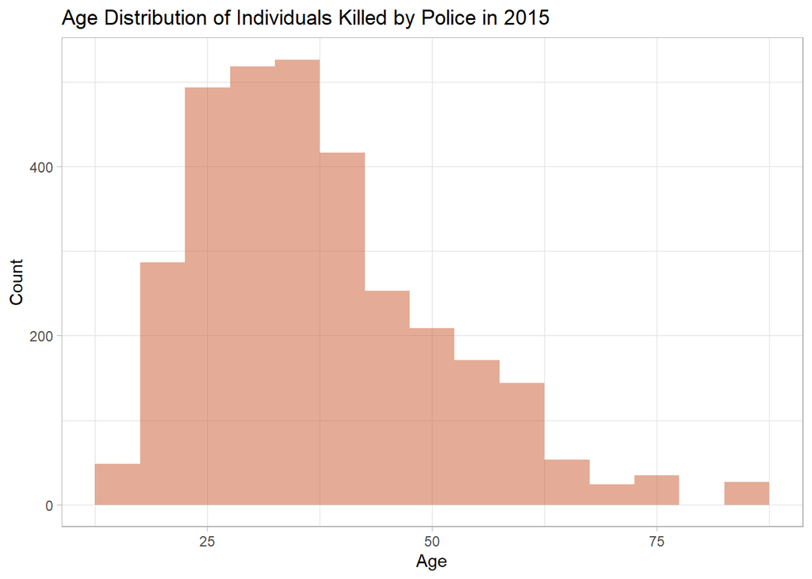

The age distribution in the dataset is characterized by a right-skewed, unimodal shape, indicating that the majority of individuals who were killed by police were relatively young. The central tendency of the age distribution can be summarized using the median, which is 35 years old.

```
## # A tibble: 1 × 4
##   min_age mean_age median_age max_age
##     <dbl>    <dbl>      <dbl>   <dbl>
## 1      16     37.3         35      87
```

```
## [1] 18
```

The dataset includes a few notable outliers, such as Louis Becker and Richard Weaver, who were 87 and 83 years old, respectively, at the time of their deaths. While these cases are relatively rare, they underscore the importance of considering age as a potential demographic factor that may influence the risk of police violence.

```
## # A tibble: 3,270 × 3
##    name           age gender
##    <chr>        <dbl> <chr>
##  1 Louis Becker    87 Male
##  2 Louis Becker    87 Male
##  3 Louis Becker    87 Male
##  4 Louis Becker    87 Male
##  5 Louis Becker    87 Male
##  6 Louis Becker    87 Male
##  7 Louis Becker    87 Male
##  8 Louis Becker    87 Male
##  9 Louis Becker    87 Male
## 10 Louis Becker    87 Male
## # … with 3,260 more rows
```

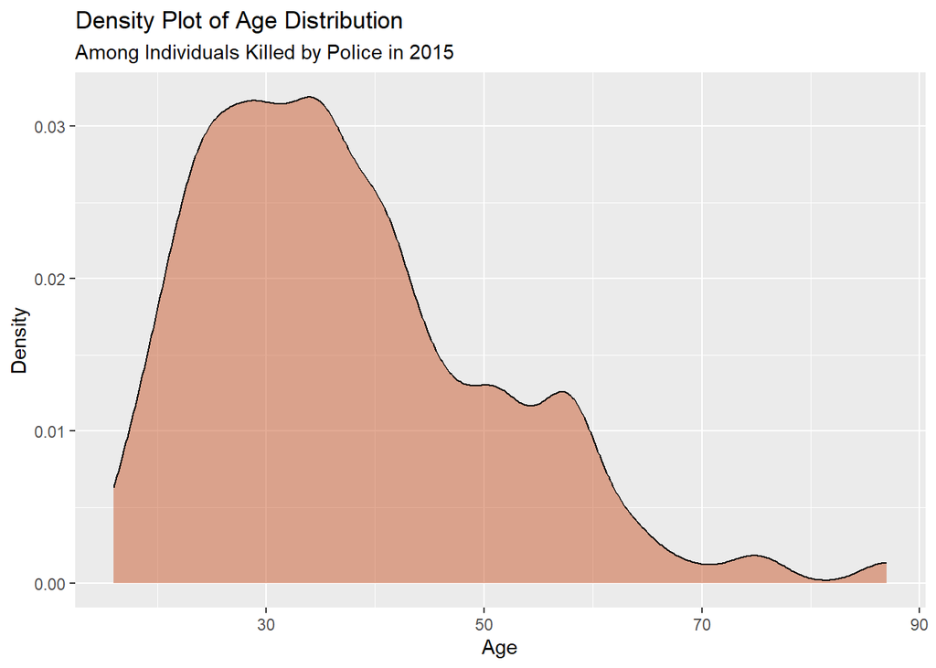

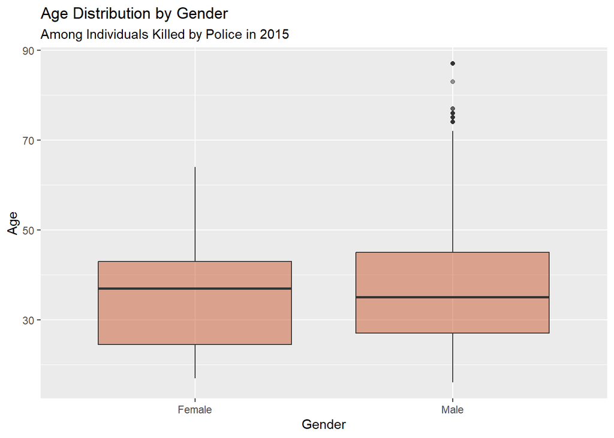

Analysis of the box plot reveals that males have a distribution with a larger range and a greater number of outliers compared to females. This pattern is particularly evident when examining the age of the individuals in the dataset, where the oldest male (Louis Becker) was 87 years old at the time of his death, while the oldest female (Hue Dang) was only 63 years old. These differences may reflect underlying demographic and societal factors that influence the likelihood of police violence and should be further investigated to better understand the root causes of these disparities.

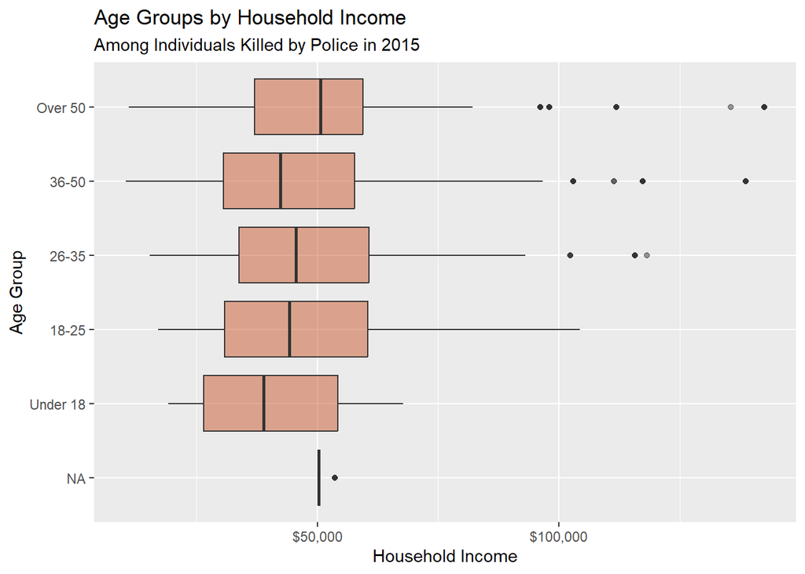

We see a general trend with indivisuals under 18 having the lowest income range(Excluding NA) among the demographic groups analyzed and indivisuals over 50 having the highest income range. indivisuals 18 to 25 show a larger interquartile range (IQR) in their income distribution compared to other age groups.

# Race/Ethnicity Summary

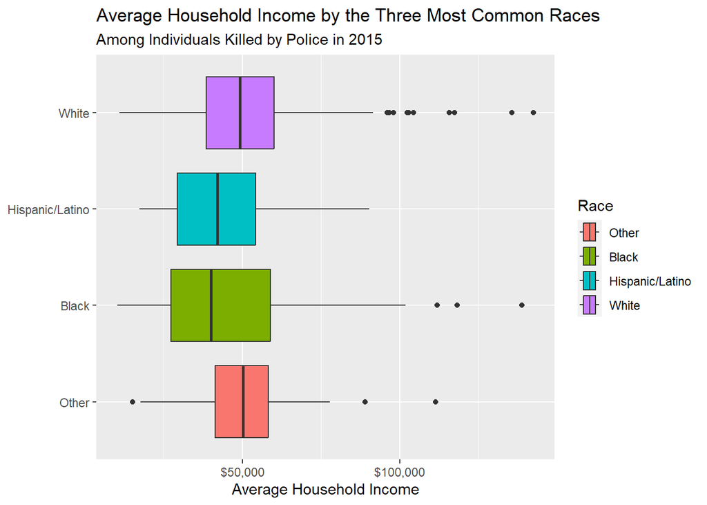

```
## # A tibble: 1 × 4
##   min_hinc mean_hinc median_hinc max_hinc
##      <dbl>     <dbl>       <dbl>    <dbl>
## 1    10290    48661.       46027   142500
```

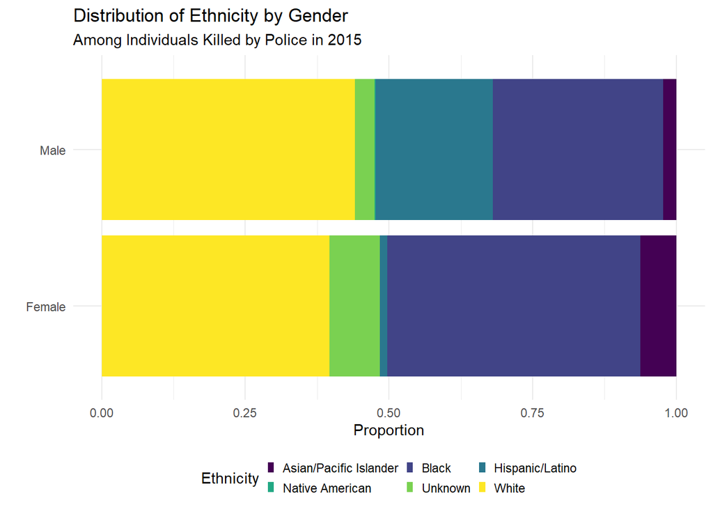

```
## # A tibble: 6 × 2
##   raceethnicity              n
##   <chr>                  <int>
## 1 White                   1433
## 2 Black                    992
## 3 Hispanic/Latino          637
## 4 Unknown                  120
## 5 Asian/Pacific Islander    81
## 6 Native American            7
```

```
## # A tibble: 11 × 4
## # Groups:   gender [2]
##    gender raceethnicity              n     pct
##    <fct>  <fct>                  <int>   <dbl>
##  1 Female Asian/Pacific Islander    10 0.0629
##  2 Female Black                     70 0.440
##  3 Female Hispanic/Latino            2 0.0126
##  4 Female Unknown                   14 0.0881
##  5 Female White                     63 0.396
##  6 Male   Asian/Pacific Islander    71 0.0228
##  7 Male   Black                    922 0.296
##  8 Male   Hispanic/Latino          635 0.204
##  9 Male   Native American            7 0.00225
## 10 Male   Unknown                  106 0.0341
## 11 Male   White                   1370 0.440
```

White men accounted for the highest proportion of police killings among all other male racial groups. at 44%

Black women accounted for the highest proportion of police killings among all female racial groups at 44%.

There is a higher proportion of male Hispanic/Latino Men(20.4%) killed than Hispanic/Latino Women(1.3%).

There is also a higher proportion of black women(44%) who were killed in comparison to black men(30%)

# Gender

```
## # A tibble: 2 × 2
##   gender     n
##   <chr>  <int>
## 1 Male    3111
## 2 Female   159
```

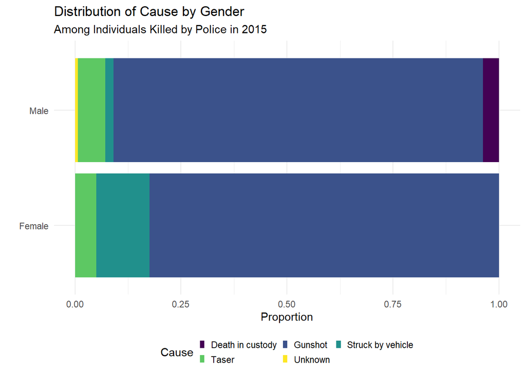

```
## # A tibble: 8 × 4
## # Groups:   gender [2]
##   gender cause                 n     pct
##   <fct>  <fct>             <int>   <dbl>
## 1 Female Gunshot             131 0.824
## 2 Female Struck by vehicle    20 0.126
## 3 Female Taser                 8 0.0503
## 4 Male   Death in custody    118 0.0379
## 5 Male   Gunshot            2710 0.871
## 6 Male   Struck by vehicle    62 0.0199
## 7 Male   Taser               200 0.0643
## 8 Male   Unknown              21 0.00675
```

82% of women and 87% of men were killed by gunshots, which is a common method used by law enforcement.

5% of women were killed by tasers versus 6.4% of men.

It is also very important to note that only male victims had a proportion(3.8%) of individuals who died in custody.

12.5% of women were killed by being struck by a vehicle versus only 2% of men.

However, it is important to investigate the proportion of these individuals who were armed at the time of the incident.

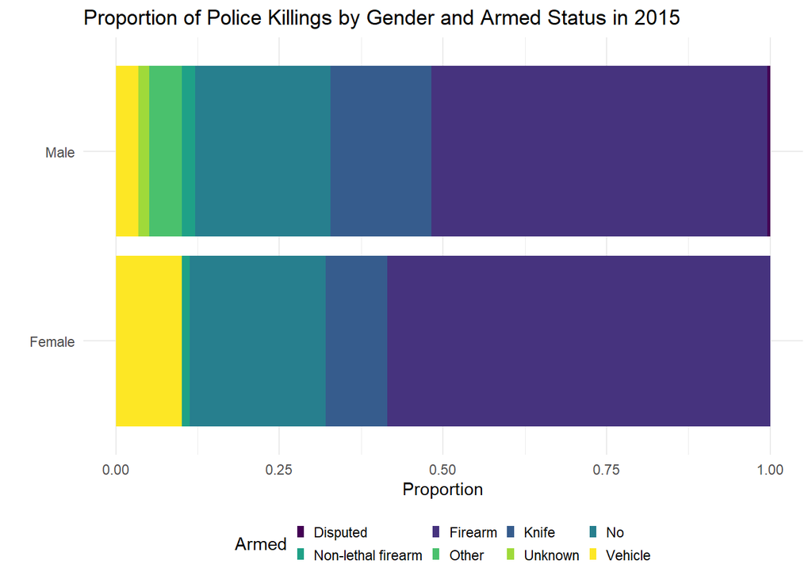

```
## # A tibble: 13 × 4
## # Groups:   gender [2]
##    gender armed                  n     pct
##    <fct>  <fct>              <int>   <dbl>
##  1 Female Firearm               93 0.585
##  2 Female Knife                 15 0.0943
##  3 Female No                    33 0.208
##  4 Female Non-lethal firearm     2 0.0126
##  5 Female Vehicle               16 0.101
##  6 Male   Disputed              14 0.00450
##  7 Male   Firearm             1598 0.514
##  8 Male   Knife                479 0.154
##  9 Male   No                   644 0.207
## 10 Male   Non-lethal firearm    62 0.0199
## 11 Male   Other                156 0.0501
## 12 Male   Unknown               51 0.0164
## 13 Male   Vehicle              107 0.0344
```

The data shows that 58.5% of women were carrying a firearm at the time of their killing versus only 51.4% of men

A higher proportion of men were killed while carrying a knife(15.4%) than women(9.4%).

A relatively equal proportion of both men and women were killed while having no weapon in hand.

This information is relevant to answering the general research question because it suggests a potential association between being armed and being perceived as a threat.

# Summarize State Killings

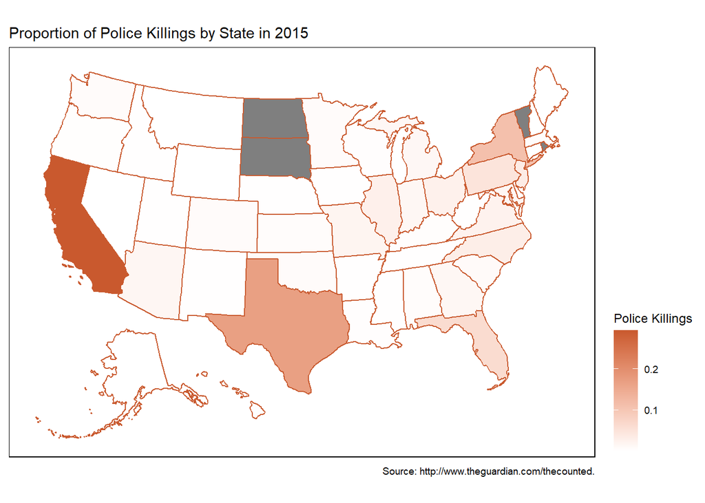

The gray plots in the visualization indicate states (South/North Dakota, Vermont, Rhode Island) that the current dataset(as of June 2,2015) does not have any information on police killings in the area, which limits the completeness of the dataset. Future research could benefit from examining specific states with high numbers of police killings, such as California and Texas, in order to gain a more detailed understanding of the patterns and trends in police violence in those areas.

# Law Enforcement Summary

```r
pk %>%
  count(lawenforcementagency) %>%
  arrange(desc(n))
```

```
## # A tibble: 377 × 2
##    lawenforcementagency                        n
##    <chr>                                   <int>
##  1 Los Angeles Police Department             130
##  2 New York Police Department                104
##  3 Pennsylvania State Police                  66
##  4 Los Angeles County Sheriff's Department    65
##  5 Fort Worth Police Department               48
##  6 San Francisco Police Department            39
##  7 Austin Police Department                   36
##  8 El Paso Police Department                  36
##  9 San Antonio Police Department              36
## 10 New Jersey State Police                    30
## # … with 367 more rows
```

# Linear Models

Is there a relationship between Household Income and age?

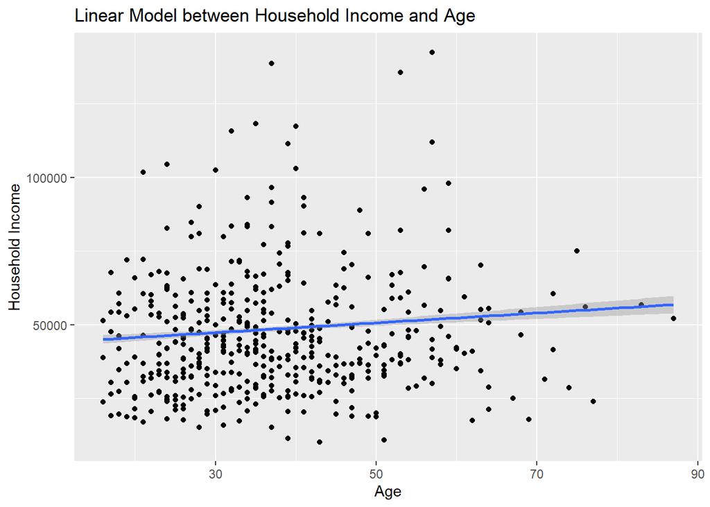

Based on the presented graph, it can be observed that there is a negligible correlation between the age and household income of the individuals who were killed by the police in the United States in 2015. This suggests that a linear model may not be appropriate to describe this relationship. As a matter of fact, I experimented with several linear models to explore potential relationships but discovered a comparable absence of correlation.

# Logistic Reggression

Response Variable Race/Ethnicity

```
## # A tibble: 2 × 2
##   minority mean_age
##   <fct>       <dbl>
## 1 0            33.5
## 2 1            41.5
```

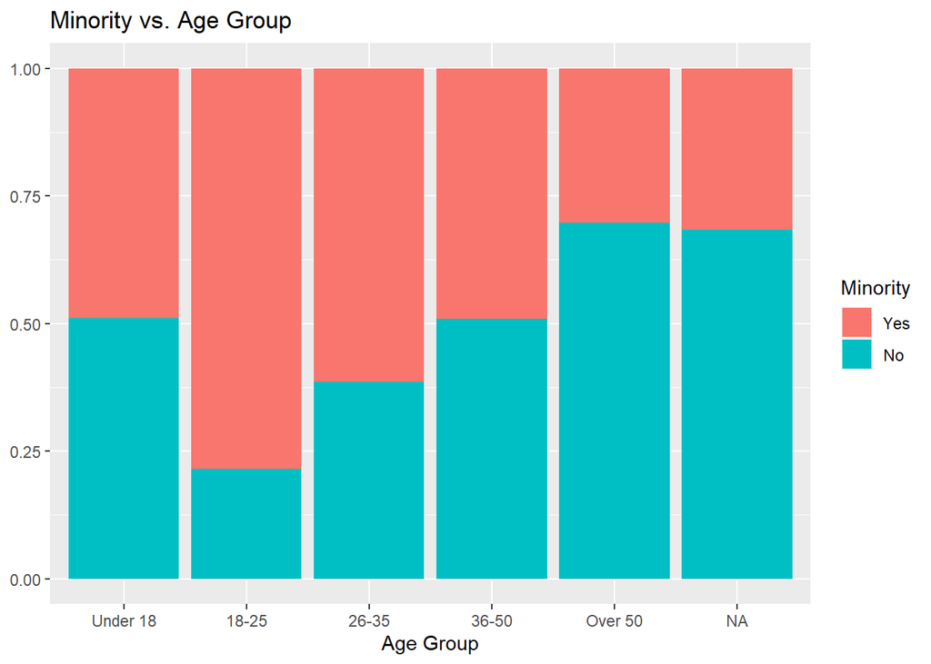

It is apparent that a larger number of minorities who were killed by the police in 2015 fell within the 18-25 age group, whereas more non-minorities were killed when they were over 50 or their age was unknown.

# Model Creation

The objective was to develop two models: one based on significant p-values and the other containing all potential useful interactions for the analysis.

```
## # A tibble: 22 × 5
##    term                    estimate std.error statistic  p.value
##    <chr>                      <dbl>     <dbl>     <dbl>    <dbl>
##  1 (Intercept)             -16.8    245.        -0.0687 9.45e- 1
##  2 age                       0.0580   0.00375   15.5    7.36e-54
##  3 armedFirearm             13.9    245.         0.0570 9.55e- 1
##  4 armedKnife               13.4    245.         0.0548 9.56e- 1
##  5 armedNo                  13.2    245.         0.0539 9.57e- 1
##  6 armedNon-lethal firearm  13.5    245.         0.0552 9.56e- 1
##  7 armedOther               14.0    245.         0.0573 9.54e- 1
##  8 armedUnknown             14.2    245.         0.0579 9.54e- 1
##  9 armedVehicle             13.1    245.         0.0535 9.57e- 1
## 10 regionMidwest             0.567    0.340      1.67   9.54e- 2
## # … with 12 more rows
```

$\widehat{minority} = -16.818 + 0.058age + 13.947armedFirearm + 13.410armedKnife + 13.208No + 13.52armedNon-lethal firearm + 14.027armedOther + 14.163armedUnknown + 13.104armedVehicle + 0.567regionMidwest - 0.125regionNortheast - 0.167regionSouth - 0.710regionSouthwest - 0.377regionWest - 4.940urate + 0.602college + 2.371causeGunshot + 1.308causeStruck by vehicle + 1.318causeTaser + 2.223causeUnknown + 0.00001939387h_income - 0.00002999880county_income$

```
## # A tibble: 14 × 5
##    term                     estimate  std.error statistic  p.value
##    <chr>                       <dbl>      <dbl>     <dbl>    <dbl>
##  1 (Intercept)            -2.77      0.490         -5.67  1.46e- 8
##  2 age                     0.0549    0.00362       15.1   8.07e-52
##  3 h_income                0.0000193 0.00000254     7.63  2.35e-14
##  4 regionMidwest           0.472     0.332          1.42  1.56e- 1
##  5 regionNortheast        -0.150     0.323         -0.465 6.42e- 1
##  6 regionSouth            -0.175     0.324         -0.540 5.89e- 1
##  7 regionSouthwest        -0.863     0.321         -2.69  7.25e- 3
##  8 regionWest             -0.373     0.319         -1.17  2.42e- 1
##  9 causeGunshot            2.27      0.281          8.11  5.16e-16
## 10 causeStruck by vehicle  1.28      0.378          3.40  6.69e- 4
## 11 causeTaser              1.44      0.326          4.40  1.07e- 5
## 12 causeUnknown            2.29      0.579          3.95  7.80e- 5
## 13 urate                  -5.56      0.792         -7.02  2.17e-12
## 14 county_income          -0.0000288 0.00000375    -7.69  1.45e-14
```

```
##
## Call:
## glm(formula = minority ~ age + armed + region + urate + college +
##     cause + h_income + county_income, family = "binomial", data = pk_race_cat)
##
## Deviance Residuals:
##     Min       1Q   Median       3Q      Max
## -2.1168  -0.9093  -0.5037   0.9523   2.7049
##
## Coefficients:
##                              Estimate    Std. Error z value
## (Intercept)             -16.818304683 244.829508243  -0.069
## age                       0.058019118   0.003754886  15.452
## armedFirearm             13.947173538 244.828978631   0.057
## armedKnife               13.409618382 244.829000438   0.055
## armedNo                  13.208380316 244.828996278   0.054
## armedNon-lethal firearm  13.516789283 244.829252397   0.055
## armedOther               14.027322307 244.829057910   0.057
## armedUnknown             14.163486293 244.829212761   0.058
## armedVehicle             13.103997288 244.829069034   0.054
## regionMidwest             0.566640737   0.339813923   1.668
## regionNortheast          -0.124973842   0.328850932  -0.380
## regionSouth              -0.167134318   0.329170638  -0.508
## regionSouthwest          -0.710162288   0.326907610  -2.172
## regionWest               -0.376822176   0.324706528  -1.161
## urate                    -4.939535740   0.825325560  -5.985
## college                   0.602220197   0.392902845   1.533
## causeGunshot              2.370671863   0.286071826   8.287
## causeStruck by vehicle    1.308282897   0.389908084   3.355
## causeTaser                1.317555049   0.332234327   3.966
## causeUnknown              2.223230576   0.606629187   3.665
## h_income                  0.000019394   0.000003212   6.038
## county_income            -0.000029999   0.000003827  -7.839
##                                     Pr(>|z|)
## (Intercept)                         0.945233
## age                     < 0.0000000000000002 ***
## armedFirearm                        0.954571
## armedKnife                          0.956321
## armedNo                             0.956975
## armedNon-lethal firearm             0.955972
```

[output cut: 12 more lines]

```
## causeTaser               0.00007316850567877 ***
## causeUnknown                        0.000247 ***
## h_income                 0.00000000156146389 ***
## county_income            0.00000000000000453 ***
## ---
## Signif. codes:  0 '***' 0.001 '**' 0.01 '*' 0.05 '.' 0.1 ' ' 1
##
## (Dispersion parameter for binomial family taken to be 1)
##
##     Null deviance: 4238.9  on 3078  degrees of freedom
## Residual deviance: 3474.8  on 3057  degrees of freedom
##   (71 observations deleted due to missingness)
## AIC: 3518.8
##
## Number of Fisher Scoring iterations: 13
```

```
##
## Call:
## glm(formula = minority ~ age + h_income + region + cause + urate +
##     county_income, family = "binomial", data = pk_race_cat)
##
## Deviance Residuals:
##     Min       1Q   Median       3Q      Max
## -2.0888  -0.9057  -0.5224   1.0093   2.5690
##
## Coefficients:
##                            Estimate   Std. Error z value             Pr(>|z|)
## (Intercept)            -2.774099591  0.489629769  -5.666 0.000000014641818101
## age                     0.054885504  0.003623801  15.146 < 0.0000000000000002
## h_income                0.000019349  0.000002536   7.630 0.000000000000023490
## regionMidwest           0.471647007  0.332258576   1.420             0.155748
## regionNortheast        -0.150363735  0.323163350  -0.465             0.641726
## regionSouth            -0.175090233  0.323981225  -0.540             0.588898
## regionSouthwest        -0.862724122  0.321278783  -2.685             0.007247
## regionWest             -0.373430744  0.318907629  -1.171             0.241611
## causeGunshot            2.274865680  0.280584298   8.108 0.000000000000000516
## causeStruck by vehicle  1.284461815  0.377546469   3.402             0.000669
## causeTaser              1.435308735  0.326075623   4.402 0.000010737310312325
## causeUnknown            2.288662546  0.579361597   3.950 0.000078047426429698
## urate                  -5.559130219  0.791521999  -7.023 0.000000000002166221
## county_income          -0.000028821  0.000003747  -7.692 0.000000000000014519
##
## (Intercept)            ***
## age                    ***
## h_income               ***
## regionMidwest
## regionNortheast
## regionSouth
## regionSouthwest        **
## regionWest
## causeGunshot           ***
## causeStruck by vehicle ***
## causeTaser             ***
## causeUnknown           ***
## urate                  ***
## county_income          ***
## ---
## Signif. codes:  0 '***' 0.001 '**' 0.01 '*' 0.05 '.' 0.1 ' ' 1
##
## (Dispersion parameter for binomial family taken to be 1)
##
##     Null deviance: 4238.9  on 3078  degrees of freedom
## Residual deviance: 3551.1  on 3065  degrees of freedom
##   (71 observations deleted due to missingness)
## AIC: 3579.1
##
## Number of Fisher Scoring iterations: 4
```

```
## Analysis of Deviance Table
##
## Model 1: minority ~ age + armed + region + urate + college + cause + h_income +
##     county_income
## Model 2: minority ~ age + h_income + region + cause + urate + county_income
##   Resid. Df Resid. Dev Df Deviance
## 1      3057     3474.8
## 2      3065     3551.1 -8  -76.325
```

- m_fit: AIC: 3518.8
- m_fit2: AIC: 3579.1

Based on the AIC values obtained, we can see that the larger model (m_fit) has a lower AIC than the smaller model (m_fit2), despite some of the interactions not being significant based on the p-values. A lower AIC suggests that the larger model should have better predictive ability. While adding more variables can sometimes decrease predictive accuracy, the Anova Test confirms the improvement in AIC between the two models. Therefore, we can conclude that variables such as college and armed are useful for the model despite some of the interactions not being significant based on the p-values.

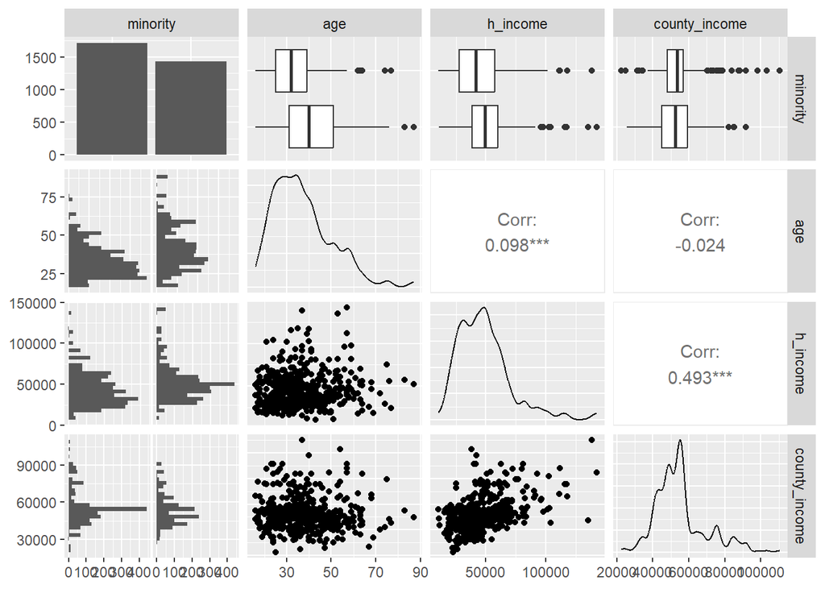

```r
pk_race_cat %>%
  select(minority, age, h_income, county_income) %>%
  ggpairs()
```

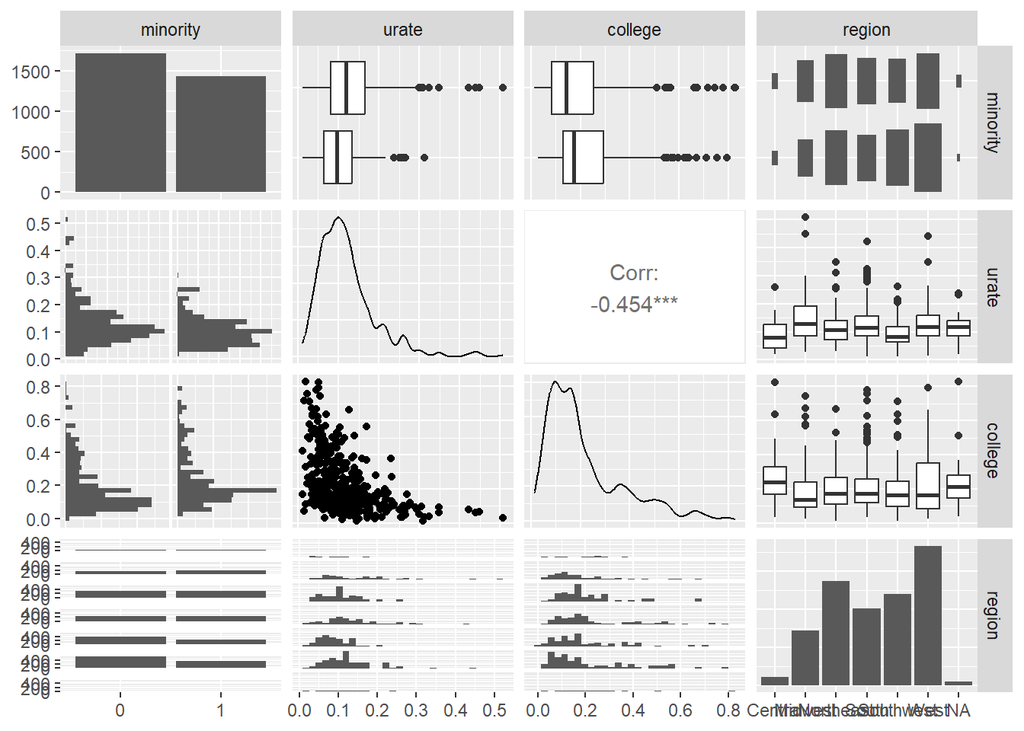

```r
pk_race_cat %>%
  select(minority, urate, college, region) %>%
  ggpairs()
```

# Predictions Based on Just Age

By far, age seems to be the most significant interaction based on p-value. Breaking down the specific connection between age and minority may be worthwhile.

```
## # A tibble: 2 × 5
##   term        estimate std.error statistic  p.value
##   <chr>          <dbl>     <dbl>     <dbl>    <dbl>
## 1 (Intercept)  -2.05     0.122       -16.8 3.25e-63
## 2 age           0.0501   0.00315      15.9 8.19e-57
```

```r
newdata <- tibble(age = c(18, 37, 52))
minority_fit %>% predict(newdata, type = "response" )
```

```
##         1         2         3
## 0.2401395 0.4500058 0.6342176
```

Based on the analysis, the following probabilities were observed:

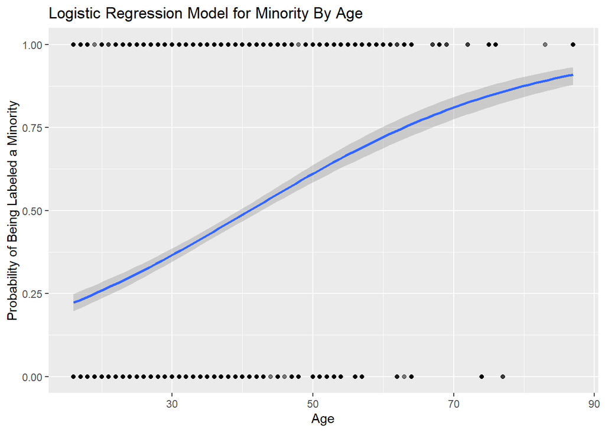

# Back to Full Model Prediction Building

```
## Rows: 2,520
## Columns: 37
## $ name                 <chr> "Dennis Fiel", "Monique Deckard", "Denis Reyes", …
## $ age                  <dbl> 34, 43, 40, 41, 33, 34, 31, 35, 24, 27, 87, 37, 3…
## $ gender               <chr> "Male", "Female", "Male", "Male", "Male", "Male",…
## $ raceethnicity        <chr> "White", "Black", "Hispanic/Latino", "Black", "Hi…
## $ month                <chr> "May", "March", "May", "January", "January", "Mar…
## $ day                  <dbl> 17, 8, 15, 7, 26, 1, 31, 2, 25, 9, 14, 8, 1, 5, 1…
## $ year                 <dbl> 2015, 2015, 2015, 2015, 2015, 2015, 2015, 2015, 2…
## $ streetaddress        <chr> "7700 Mesa College Dr", "900 S Euclid St", "274 E…
## $ city                 <chr> "San Diego", "Anaheim", "New York", "Columbus", "…
## $ state                <chr> "CA", "CA", "NY", "OH", "CA", "MO", "TX", "TX", "…
## $ latitude             <dbl> 32.80196, 33.82007, 40.86462, 39.99751, 35.58907,…
## $ longitude            <dbl> -117.15433, -117.94138, -73.89243, -82.89005, -11…
## $ state_fp             <dbl> 6, 6, 36, 39, 6, 29, 48, 48, 36, 13, 36, 51, 34, …
```

[output cut: 24 more lines]

```
## Rows: 630
## Columns: 37
## $ name                 <chr> "A'donte Washington", "Aaron Siler", "Adam Jovici…
## $ age                  <dbl> 16, 26, 29, 22, 35, 35, 35, 31, 31, 76, 40, 40, N…
## $ gender               <chr> "Male", "Male", "Male", "Male", "Male", "Male", "…
## $ raceethnicity        <chr> "Black", "White", "White", "Hispanic/Latino", "Hi…
## $ month                <chr> "February", "March", "March", "March", "March", "…
## $ day                  <dbl> 23, 14, 19, 27, 26, 26, 26, 7, 7, 26, 12, 12, 20,…
## $ year                 <dbl> 2015, 2015, 2015, 2015, 2015, 2015, 2015, 2015, 2…
## $ streetaddress        <chr> "Clearview Ln", "22nd Ave and 56th St", "364 Hiwo…
## $ city                 <chr> "Millbrook", "Kenosha", "Munroe Falls", "Bakersfi…
## $ state                <chr> "AL", "WI", "OH", "CA", "CA", "CA", "CA", "MI", "…
## $ latitude             <dbl> 32.52958, 42.58356, 41.14857, 35.39570, 33.79305,…
## $ longitude            <dbl> -86.36283, -87.83571, -81.42988, -119.00274, -118…
## $ state_fp             <dbl> 1, 55, 39, 6, 6, 6, 6, 26, 26, 6, 6, 6, 48, 48, 4…
```

[output cut: 24 more lines]

Initially, I divided the data into two sets: the Training set and the Testing set. The Training set, which comprises the majority of the data (usually 80%), is used for developing the model. It is essential to spend most of the time using the Training set to build the model. On the other hand, the Testing set, which contains the remaining data (usually 20%), is held in reserve to evaluate the effectiveness of one or two selected models. It is crucial to only look at the Testing set once, as it should not be a continuous part of the modeling process.

# Larger Model

```
## # A tibble: 630 × 10
##     pred minority   age region   urate college county_income h_inc…¹ cause armed
##    <dbl> <fct>    <dbl> <chr>    <dbl>   <dbl>         <dbl>   <dbl> <chr> <chr>
##  1 0.182 0           16 South   0.0977  0.169          54766   51367 Guns… No
##  2 0.340 1           26 Midwest 0.166   0.147          54930   45365 Guns… No
##  3 0.686 1           29 Midwest 0.0635  0.404          49669   68785 Guns… No
##  4 0.388 0           22 West    0.131   0.204          48552   58068 Guns… Fire…
##  5 0.481 0           35 West    0.0943  0.0904         55909   66543 Guns… Non-…
##  6 0.481 0           35 West    0.0943  0.0904         55909   66543 Guns… Non-…
##  7 0.481 0           35 West    0.0943  0.0904         55909   66543 Guns… Non-…
##  8 0.613 1           31 Midwest 0.174   0.103          51667   44553 Guns… Other
##  9 0.613 1           31 Midwest 0.174   0.103          51667   44553 Guns… Other
## 10 0.924 1           76 West    0.0411  0.100          48133   56065 Guns… Knife
## # … with 620 more rows, and abbreviated variable name ¹h_income
```

```
## Confusion Matrix and Statistics
##
##           Reference
## Prediction   0   1
##          0 266  94
##          1  73 179
##
##                Accuracy : 0.7271
##                  95% CI : (0.69, 0.7621)
##     No Information Rate : 0.5539
##     P-Value [Acc > NIR] : <0.0000000000000002
##
##                   Kappa : 0.4437
##
##  Mcnemar's Test P-Value : 0.1217
##
##             Sensitivity : 0.7847
##             Specificity : 0.6557
##          Pos Pred Value : 0.7389
##          Neg Pred Value : 0.7103
##              Prevalence : 0.5539
##          Detection Rate : 0.4346
##    Detection Prevalence : 0.5882
##       Balanced Accuracy : 0.7202
##
##        'Positive' Class : 0
##
```

# Smaller Model

```
## # A tibble: 630 × 8
##     pred minority   age region   urate college county_income h_income
##    <dbl> <fct>    <dbl> <chr>    <dbl>   <dbl>         <dbl>    <dbl>
##  1 0.284 0           16 South   0.0977  0.169          54766    51367
##  2 0.443 1           26 Midwest 0.166   0.147          54930    45365
##  3 0.752 1           29 Midwest 0.0635  0.404          49669    68785
##  4 0.338 0           22 West    0.131   0.204          48552    58068
##  5 0.550 0           35 West    0.0943  0.0904         55909    66543
##  6 0.550 0           35 West    0.0943  0.0904         55909    66543
##  7 0.550 0           35 West    0.0943  0.0904         55909    66543
##  8 0.520 1           31 Midwest 0.174   0.103          51667    44553
##  9 0.520 1           31 Midwest 0.174   0.103          51667    44553
## 10 0.941 1           76 West    0.0411  0.100          48133    56065
## # … with 620 more rows
```

```
## Confusion Matrix and Statistics
##
##           Reference
## Prediction   0   1
##          0 256  94
##          1  83 179
##
##                Accuracy : 0.7108
##                  95% CI : (0.6731, 0.7464)
##     No Information Rate : 0.5539
##     P-Value [Acc > NIR] : 0.000000000000001137
##
##                   Kappa : 0.4125
##
##  Mcnemar's Test P-Value : 0.4523
##
##             Sensitivity : 0.7552
##             Specificity : 0.6557
##          Pos Pred Value : 0.7314
##          Neg Pred Value : 0.6832
##              Prevalence : 0.5539
##          Detection Rate : 0.4183
##    Detection Prevalence : 0.5719
##       Balanced Accuracy : 0.7054
##
##        'Positive' Class : 0
##
```

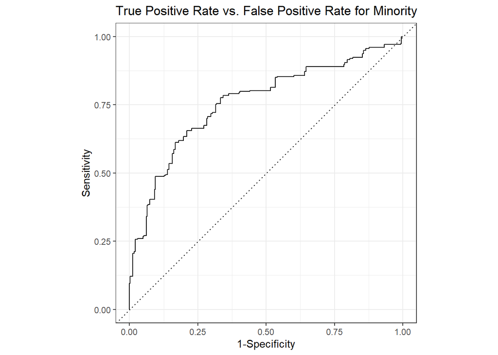

```
## # A tibble: 1 × 3
##   .metric .estimator .estimate
##   <chr>   <chr>          <dbl>
## 1 roc_auc binary         0.759
```

The models AUC is 75.9, indicates that the model performs reasonably well in distinguishing between positive and negative cases. The higher the AUC, the better the model’s ability to differentiate between the two classes. In general, an AUC above 70% is considered good, while an AUC above 90% is considered excellent.

# Final Predictions

Based on the logistic regression model we have built, we can make a prediction for whether or not a person with the given parameters is a minority or non-minority.

Lets say, for example, That The person in question is 23 years old, unarmed, from the south region, has a low unemployment rate of 0.03859900, a college rate of 0.5266234, a household income of 57174, a county income of 66006, and the cause of death is listed as gunshot.

```r
newdata <- tibble(age=23,region="South",urate=0.03859900,college=0.5266234,cause="Gunshot",armed="No",h_income=57174,county_income=66006)
m_fit %>% predict(newdata, type = "response")
```

```
##        1
## 0.306456
```

The model’s computed probability that this person is a minority is 30.64%.

# Conclusion

Interestingly, White men accounted for the highest proportion of police killings among all other male racial groups at 44%. However, There were more stark differences in the distribution of ethnicity for males and females within the minority groups, with more Hispanic/Latino men killed than women, and a higher proportion of black women killed compared to black men.

Furthermore, the regression models showed that variables such as household income, county income, and unemployment rate were correlated with each other, but not to a degree that would warrant their removal from the model. The inclusion of certain variables such as college and armed status also improved the accuracy of the model. To improve the analysis, future research could consider including additional variables such as the ethnicity of the police officer involved. Additionally, exploring the impact of police training and community policing initiatives on the incidence of police killings could provide valuable insights.

In conclusion, the analysis revealed patterns and trends in police killings in the United States in 2015 that were influenced by demographic factors. The findings provide important insights that can inform policy and training initiatives aimed at reducing the incidence of police killings in the United States.